# Graphs in Python: Symbols, Line Styles and Colours

⇦ Back

# 1 Plot Symbols

By default, there are 39 symbols that can be used for the data points of a **plot** or a **scatter** graph. These are set using the `marker` keyword argument as follows:

```python
ax.plot(x, y, marker='.')
```

The above will create a graph using a **point** as the plot symbol for each data point. Here’s a dictionary of the full set of options:

```python
symbols = {
    'point': '.',
    'pixel': ',',
    'circle': 'o',
    'triangle_down': 'v',
    'triangle_up': '^',
    'triangle_left': '<',
    'triangle_right': '>',
    'tri_down': '1',
    'tri_up': '2',
    'tri_left': '3',
    'tri_right': '4',
    'octagon': '8',
    'square': 's',
    'pentagon': 'p',
    'plus (filled)': 'P',
    'star': '*',
    'hexagon1': 'h',
    'hexagon2': 'H',
    'plus': '+',
    'x': 'x',
    'x (filled)': 'X',
    'diamond': 'D',
    'thin_diamond': 'd',
    'vline': '|',
    'hline': '_',
    'tickleft': 0,
    'tickright': 1,
    'tickup': 2,
    'tickdown': 3,
    'caretleft (centred)': 4,
    'caretright (centred)': 5,
    'caretup (centred)': 6,
    'caretdown (centred)': 7,
    'caretleft': 8,
    'caretright': 9,
    'caretup': 10,
    'caretdown': 11,
    'nothing': '',
    'mathtext': '$f$',
}
```

Here’s a plot that shows off the full range of options:

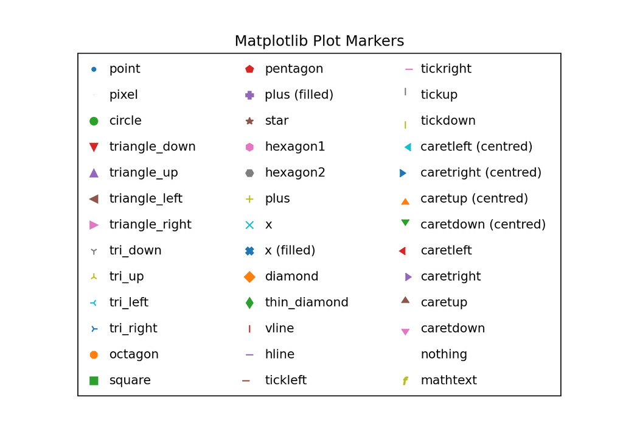

```python
import matplotlib.pyplot as plt
import numpy as np

# Create axes
ax = plt.axes()
ax.set(
    title='Matplotlib Plot Markers'
)
for i, symbol in enumerate(symbols):
    x = int(np.floor(i / 13) + 1)
    y = 13 - i % 13 + 0.15
    key = list(symbols.keys())[i]
    marker = symbols[key]
    ax.plot([x], [y], marker=marker)
    x = np.floor(i / 13) + 1.1
    y = 13 - i % 13
    ax.annotate(key, [x, y])
# Turn off axis ticks and tick labels
plt.tick_params(axis='x', bottom=False, labelbottom=False)
plt.tick_params(axis='y', left=False, labelleft=False)
# Set the axis limits
ax.set_xlim(0.9, 4)
# Output
plt.show()
plt.close()
```

For more info, see [the Matplotlib documentation](https://matplotlib.org/3.2.1/api/markers_api.html).

# 2 Line Styles

Similarly, the style of line that is plotted can be controlled with the `linestyle` or `ls` keyword argument, for example:

```python
ax.plot(x, y, linestyle='-')
```

…will plot a solid line, which is also the default (ie if you omit the `linestyle` argument it with use this). The line styles that can be used are as follows:

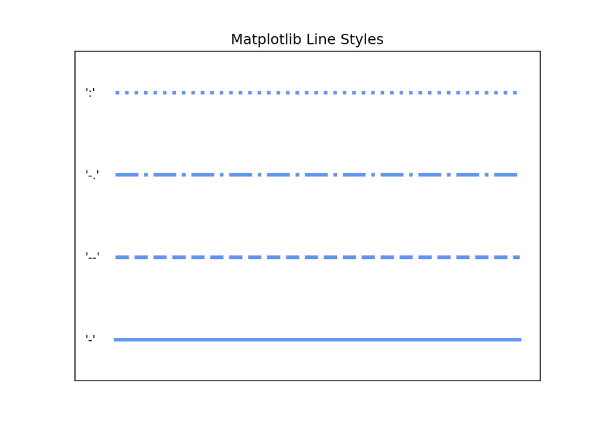

```python
linestyles = ['-', '--', '-.', ':']

# Create axes
ax = plt.axes()
ax.set(
    title='Matplotlib Line Styles'
)
for i, linestyle in enumerate(linestyles):
    ax.plot(
        [0, 2], [i, i],
        linestyle=linestyle,
        color='cornflowerblue',
        linewidth=3
    )
    ax.text(-0.15, i - 0.05, repr(linestyle))
# Turn off axis ticks and tick labels
plt.tick_params(axis='x', bottom=False, labelbottom=False)
plt.tick_params(axis='y', left=False, labelleft=False)
# Set the axis limits
ax.set_xlim(-0.2, 2.1)
ax.set_ylim(-0.5, 3.5)
# Output
plt.show()
plt.close()
```

The documentation is [here](https://matplotlib.org/gallery/lines_bars_and_markers/line_styles_reference.html).

# 3 Colours

The colour of a plot can be specified using the `color` or `c` keyword argument. Some of the available options are illustrated below:

```python
import matplotlib.pyplot as plt
import matplotlib.colors as mcolors


def plot_colortable(colors, title, sort_colors=True, emptycols=0):
    cell_width = 212
    cell_height = 22
    swatch_width = 48
    margin = 12
    topmargin = 40

    # Sort colors by hue, saturation, value and name
    if sort_colors is True:
        by_hsv = sorted(
            (tuple(mcolors.rgb_to_hsv(mcolors.to_rgb(color))), name)
            for name, color in colors.items()
        )
        names = [name for hsv, name in by_hsv]
    else:
        names = list(colors)

    n = len(names)
    ncols = 4 - emptycols
    nrows = n // ncols + int(n % ncols > 0)

    width = cell_width * 4 + 2 * margin
    height = cell_height * nrows + margin + topmargin
    dpi = 72

    fig, ax = plt.subplots(figsize=(width / dpi, height / dpi), dpi=dpi)
    fig.subplots_adjust(
        margin / width, margin / height,
        (width - margin) / width, (height - topmargin) / height
    )
    ax.set_xlim(0, cell_width * 4)
    ax.set_ylim(cell_height * (nrows - 0.5), -cell_height / 2.)
    ax.yaxis.set_visible(False)
    ax.xaxis.set_visible(False)
    ax.set_axis_off()
    ax.set_title(title, fontsize=24, loc='left', pad=10)

    for i, name in enumerate(names):
        row = i % nrows
        col = i // nrows
        y = row * cell_height

        swatch_start_x = cell_width * col
        swatch_end_x = cell_width * col + swatch_width
        text_pos_x = cell_width * col + swatch_width + 7

        ax.text(
            text_pos_x, y, name, fontsize=14,
            horizontalalignment='left',
            verticalalignment='center'
        )

        ax.hlines(
            y, swatch_start_x, swatch_end_x,
            color=colors[name], linewidth=18
        )

    return fig
```

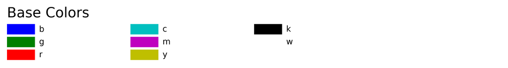

```python
plot_colortable(mcolors.BASE_COLORS, 'Base Colors', sort_colors=False, emptycols=1)
plt.show()
```

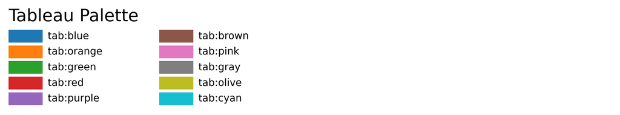

```python
plot_colortable(mcolors.TABLEAU_COLORS, 'Tableau Palette', sort_colors=False, emptycols=2)
plt.show()
```

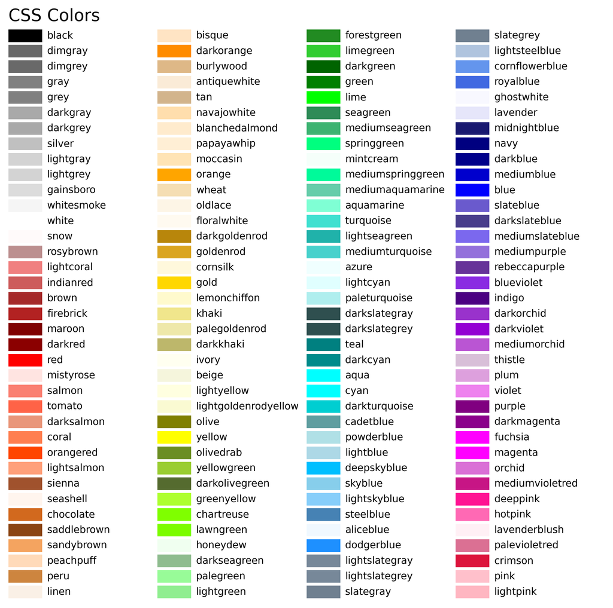

```python
plot_colortable(mcolors.CSS4_COLORS, 'CSS Colors')
plt.show()
```

```python
# Optionally plot the XKCD colors (Caution: will produce large figure)
plot_colortable(mcolors.XKCD_COLORS, 'XKCD Colors')
plt.show()
```

[output not shown]

The Matplotlib documentation is [here](https://matplotlib.org/stable/gallery/color/named_colors.html).

# 4 Hatching

If you have a shaded area, a **hatching** can be applied by using the `hatch` keyword argument. For example, `hatch='/'` will create a diagonal pattern. Here’s a demonstration of all the options:

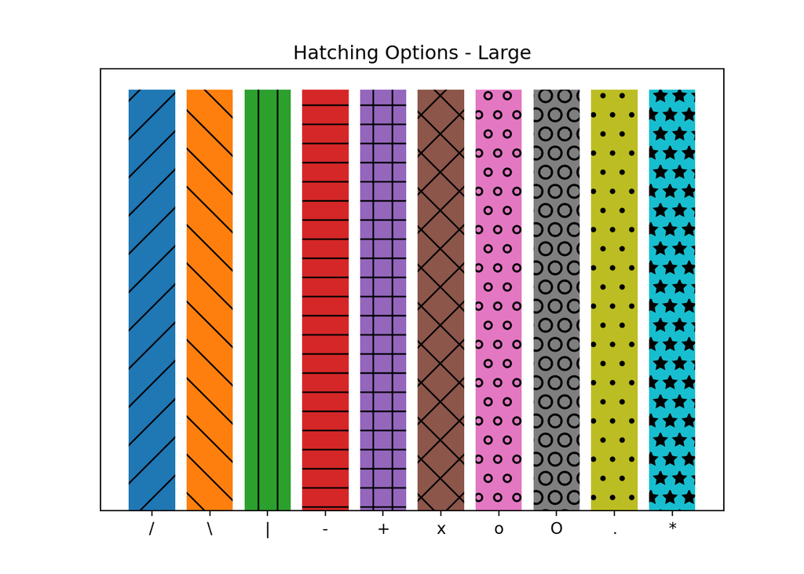

```python
import matplotlib.pyplot as plt

hatchings = ['/', '\\', '|', '-', '+', 'x', 'o', 'O', '.', '*']
for i, hatch in enumerate(hatchings):
    plt.bar(i, 1, hatch=hatch)
plt.title('Hatching Options - Large')
plt.yticks([])
plt.xticks(range(len(hatchings)), hatchings)
plt.show()
```

If you want the hatching pattern to be smaller, simply *double the character* when setting the argument. For example, `hatch='//'` will create a diagonal pattern where the lines are closer together than in the previous example where `hatch='/'` was used.

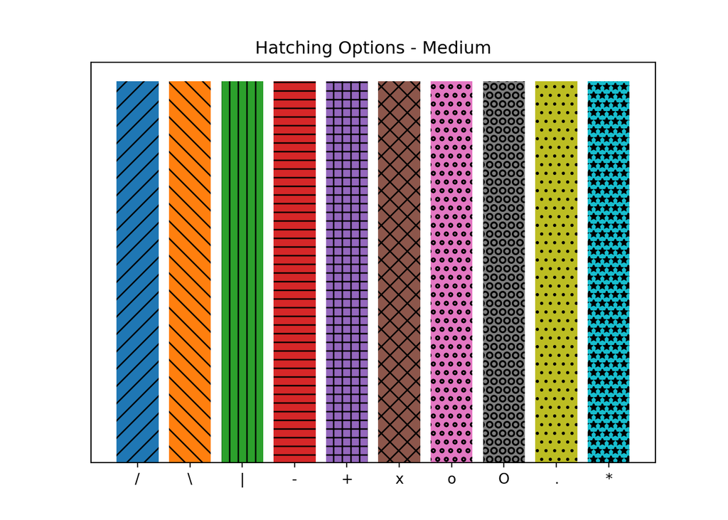

```python
hatchings_x2 = [h + h for h in hatchings]
for i, hatch in enumerate(hatchings_x2):
    plt.bar(i, 1, hatch=hatch)
plt.title('Hatching Options - Medium')
plt.yticks([])
plt.xticks(range(len(hatchings)), hatchings)
plt.show()
```

The same principle applies for three repeated characters: `hatch='///'` will make the lines closer together than `hatch='//'` will.

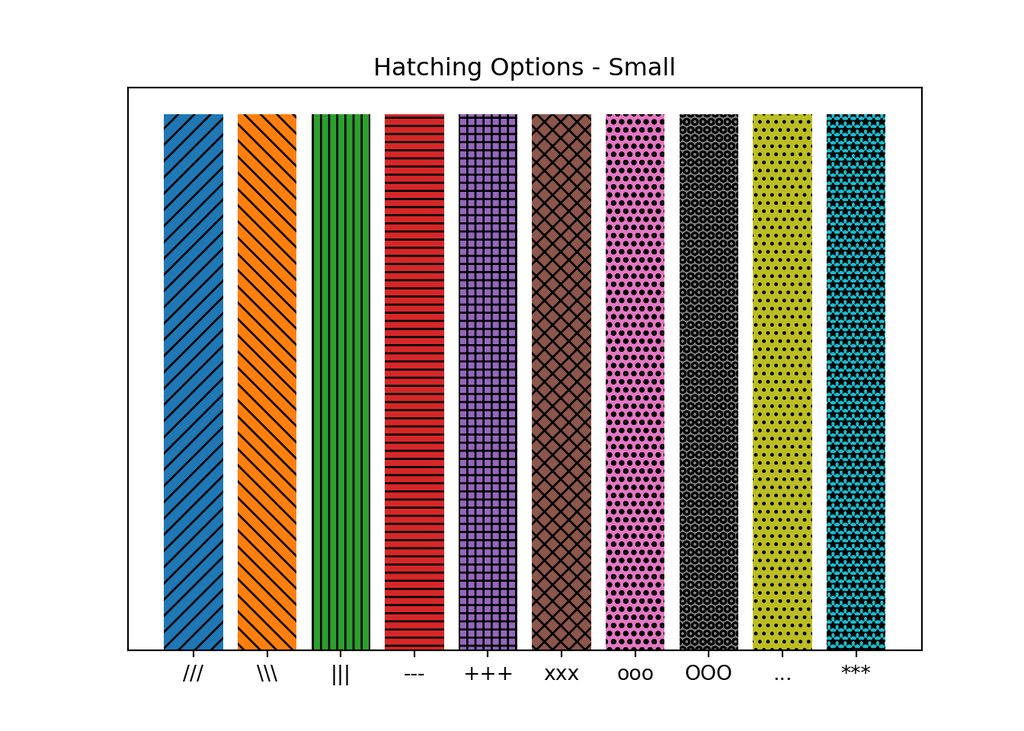

```python
hatchings_x3 = [h + h + h for h in hatchings]
for i, hatch in enumerate(hatchings_x3):
    plt.bar(i, 1, hatch=hatch)
plt.title('Hatching Options - Small')
plt.yticks([])
plt.xticks(range(len(hatchings)), hatchings_x3)
plt.show()
```

⇦ Back